# Psyc 496 Machine Learning with R Final Project

Spring 2024 Iris Shang

# Introduction

I’ll be using this dataset from Kaggle to predict bike demands: https://www.kaggle.com/c/bike-sharing-demand/data.

In urban areas, bike-sharing programs have become increasingly popular as a convenient and eco-friendly transportation option. The ability to predict demand for bike rentals can significantly enhance operational efficiency and customer satisfaction. This project aims to develop a machine learning model that forecasts the number of bicycles rented at any given hour, leveraging historical data and considering various influencing factors.

# Motivation

The motivation behind this study is to enable bike-sharing companies to optimize their fleet management, reduce costs, and improve service quality by accurately forecasting demand. Identifying the key predictors of bike rental demand and developing a reliable predictive model are the primary goals of this project.

A precise model of bike rental counts enables companies to predict demand fluctuations accurately. This can lead to more efficient distribution of bikes across the city, ensuring that bikes are available where and when they are needed most. For instance, during rush hours in commercial areas or during events and festivals in specific locations. By anticipating demand spikes and troughs, companies can avoid the twin problems of over-supply and under-supply, which respectively lead to idle bikes and unsatisfied customers.

Effective demand prediction directly impacts the cost efficiency of operations. By optimizing the allocation of bikes and reducing the need for last-minute transfers (rebalancing bikes across stations), companies can significantly cut operational costs. These include lower fuel usage, reduced labor costs, and less wear and tear on vehicles used for transferring bikes. Moreover, accurate demand forecasting can help in strategic decisions regarding purchase and maintenance cycles, ensuring that the company invests in bicycles according to actual needs rather than estimated guesses.

Customer satisfaction in bike-sharing systems heavily relies on the availability of bikes and docking points. When customers find that bikes are readily available when they need them and can easily dock them at their destination, their user experience improves, which is crucial for customer retention and service attractiveness. A good predictive model ensures that service levels meet customer expectations consistently, enhancing overall user experience and expanding the service’s user base.

Optimizing the deployment of bikes not only reduces operational costs but also minimizes the carbon footprint associated with the rebalancing of bikes using transport vehicles. Better demand prediction helps in maintaining a more statically efficient number of bikes, thereby reducing unnecessary trips to redistribute them. This contributes to the environmental goals of urban areas, promoting sustainability.

Developing an accurate predictive model of bike rental demand is not only a business imperative, but also a move toward smarter, more sustainable urban transportation solutions. It uses data to refine operational strategies, improve customer service, promote environmental sustainability, and support broader urban planning initiatives. The benefits extend beyond the immediate business, impacting urban mobility and quality of life in cities.

# Hypotheses

1. Time of Day: Bike rental demand is higher during rush hours due to people commuting to and from work.
2. Day of the Week: Weekdays have a different demand pattern compared to weekends, with potential spikes on weekends due to recreational use.
3. Weather Conditions: Clear, pleasant weather leads to higher rental demand, while extreme conditions like rain or snow reduce it.
4. Temperature: Warmer temperatures increase demand, but extremely high temperatures may deter rentals.
5. Humidity and Wind Speed: Higher humidity and wind speeds might negatively affect rental demand.
6. Seasonality: Demand varies across seasons, with spring and summer likely experiencing higher rentals.

# Data Summary

Let’s first take a look at the data summary and distribution of the variables. Since the data are all numerical, here’s some additional information that can help us understand what they mean.

**datetime**- hourly date + timestamp

**season**- 1 = spring, 2 = summer, 3 = fall, 4 = winter

**holiday** - whether the day is considered a holiday

**workingday** - whether the day is neither a weekend nor holiday

**weather**- 1: Clear, Few clouds, Partly cloudy, Partly cloudy 2: Mist + Cloudy, Mist + Broken clouds, Mist + Few clouds, Mist 3: Light Snow, Light Rain + Thunderstorm + Scattered clouds, Light Rain + Scattered clouds 4: Heavy Rain + Ice Pallets + Thunderstorm + Mist, Snow + Fog

**temp** - temperature in Celsius

**atemp** - “feels like” temperature in Celsius

**humidity** - relative humidity

**windspeed** - wind speed

**casual** - number of non-registered user rentals initiated

**registered** - number of registered user rentals initiated

**count** - number of total rentals

```r
#Read the doctument
setwd("C:/Users/tshan/Downloads/bike-sharing-demand")
library(data.table)
train_data <- read.csv("train.csv")
head(train_data)
```

|  | datetime | season | holiday | workingday | weather | temp | atemp | humidity | windspeed | casual | registered | count |
| --- | --- | --- | --- | --- | --- | --- | --- | --- | --- | --- | --- | --- |
| 1 | 2011-01-01 00:00:00 | 1 | 0 | 0 | 1 | 9.84 | 14.395 | 81 | 0.0000 | 3 | 13 | 16 |
| 2 | 2011-01-01 01:00:00 | 1 | 0 | 0 | 1 | 9.02 | 13.635 | 80 | 0.0000 | 8 | 32 | 40 |
| 3 | 2011-01-01 02:00:00 | 1 | 0 | 0 | 1 | 9.02 | 13.635 | 80 | 0.0000 | 5 | 27 | 32 |
| 4 | 2011-01-01 03:00:00 | 1 | 0 | 0 | 1 | 9.84 | 14.395 | 75 | 0.0000 | 3 | 10 | 13 |
| 5 | 2011-01-01 04:00:00 | 1 | 0 | 0 | 1 | 9.84 | 14.395 | 75 | 0.0000 | 0 | 1 | 1 |
| 6 | 2011-01-01 05:00:00 | 1 | 0 | 0 | 2 | 9.84 | 12.880 | 75 | 6.0032 | 0 | 1 | 1 |

```r
#Summary of the data
summary(train_data)
```

```
##    datetime             season         holiday          workingday
##  Length:10886       Min.   :1.000   Min.   :0.00000   Min.   :0.0000
##  Class :character   1st Qu.:2.000   1st Qu.:0.00000   1st Qu.:0.0000
##  Mode  :character   Median :3.000   Median :0.00000   Median :1.0000
##                     Mean   :2.507   Mean   :0.02857   Mean   :0.6809
##                     3rd Qu.:4.000   3rd Qu.:0.00000   3rd Qu.:1.0000
##                     Max.   :4.000   Max.   :1.00000   Max.   :1.0000
##     weather           temp           atemp          humidity
##  Min.   :1.000   Min.   : 0.82   Min.   : 0.76   Min.   :  0.00
##  1st Qu.:1.000   1st Qu.:13.94   1st Qu.:16.66   1st Qu.: 47.00
##  Median :1.000   Median :20.50   Median :24.24   Median : 62.00
##  Mean   :1.418   Mean   :20.23   Mean   :23.66   Mean   : 61.89
##  3rd Qu.:2.000   3rd Qu.:26.24   3rd Qu.:31.06   3rd Qu.: 77.00
##  Max.   :4.000   Max.   :41.00   Max.   :45.45   Max.   :100.00
##    windspeed          casual         registered        count
##  Min.   : 0.000   Min.   :  0.00   Min.   :  0.0   Min.   :  1.0
##  1st Qu.: 7.002   1st Qu.:  4.00   1st Qu.: 36.0   1st Qu.: 42.0
##  Median :12.998   Median : 17.00   Median :118.0   Median :145.0
##  Mean   :12.799   Mean   : 36.02   Mean   :155.6   Mean   :191.6
##  3rd Qu.:16.998   3rd Qu.: 49.00   3rd Qu.:222.0   3rd Qu.:284.0
##  Max.   :56.997   Max.   :367.00   Max.   :886.0   Max.   :977.0
```

# Data Processing

As we can see, the dataset includes a wide range in temperature and feels like temperature. For better model fitting, it’s better to remove those outliers. Also, we want to avoid missing data that could potentially skew the analysis, so I’m going to remove the rows with missing values.

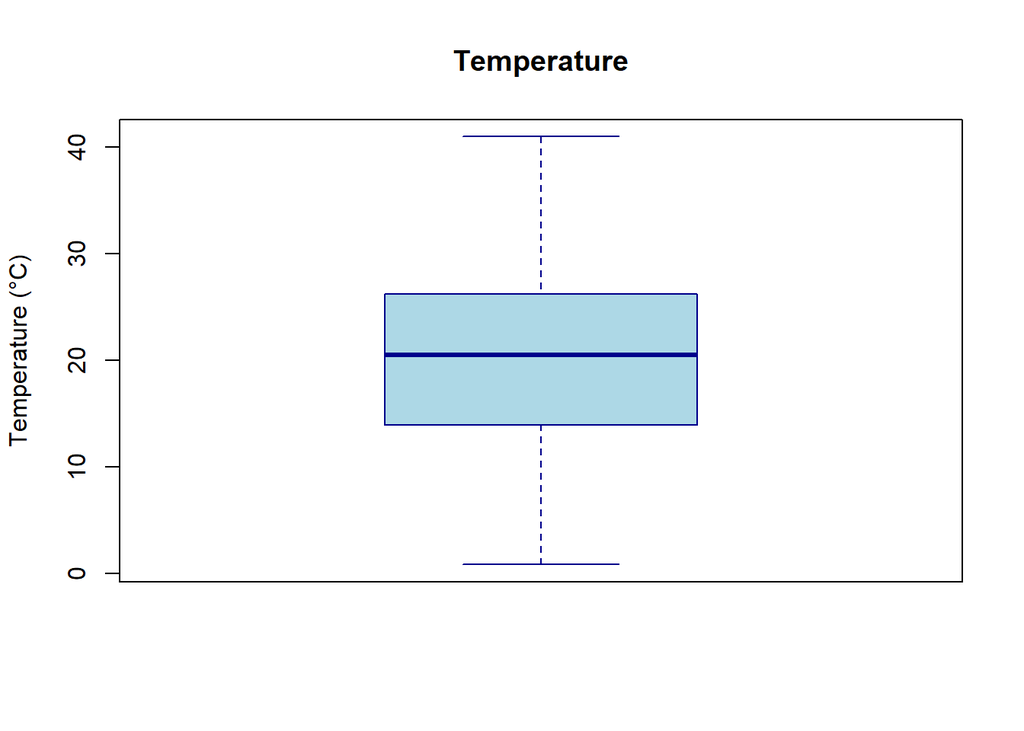

```r
# Boxplot for temperature
boxplot(train_data$temp, main="Temperature", ylab="Temperature (°C)",
        col="lightblue",
        border="darkblue",
        outpch=19,
        outcol="red")
```

```r
# Remove missing values
train_data <- na.omit(train_data)

# Removing outliers that are outside 1.5IQR for temp
Q1_temp <- quantile(train_data$temp, 0.25)
Q3_temp <- quantile(train_data$temp, 0.75)
IQR_temp <- Q3_temp - Q1_temp
train_data <- train_data[train_data$temp > (Q1_temp - 1.5*IQR_temp) & train_data$temp < (Q3_temp + 1.5*IQR_temp), ]
```

# Model Fitting and Data Analysis

To predict the bike demand from various independent variables, we need to build a model for testing all the hypothesis above.

Let’s first try the **Linear Regression Model**

```r
# Linear Regression Model Fitting
library(stats)

model_formula <- count ~ season + holiday + workingday + weather + temp + atemp + humidity + windspeed + hour(datetime) + wday(datetime) + month(datetime)

lm_model <- lm(model_formula, data=train_data)

summary(lm_model)
```

```
##
## Call:
## lm(formula = model_formula, data = train_data)
##
## Residuals:
##     Min      1Q  Median      3Q     Max
## -322.05  -96.56  -31.46   54.82  694.63
##
## Coefficients:
##                 Estimate Std. Error t value Pr(>|t|)
## (Intercept)     39.32374    9.66393   4.069 4.75e-05 ***
## season          -8.47395    5.39005  -1.572   0.1159
## holiday         -0.44338    8.87053  -0.050   0.9601
## workingday      -0.17191    3.13789  -0.055   0.9563
## weather         -2.62528    2.49240  -1.053   0.2922
## temp             2.07010    1.08231   1.913   0.0558 .
## atemp            4.60914    0.99644   4.626 3.78e-06 ***
## humidity        -2.26271    0.09127 -24.790  < 2e-16 ***
## windspeed        0.39359    0.18975   2.074   0.0381 *
## hour(datetime)   7.56319    0.21647  34.940  < 2e-16 ***
## wday(datetime)   2.10436    0.71130   2.958   0.0031 **
## month(datetime) 10.07791    1.75178   5.753 9.01e-09 ***
## ---
## Signif. codes:  0 '***' 0.001 '**' 0.01 '*' 0.05 '.' 0.1 ' ' 1
##
## Residual standard error: 147.4 on 10874 degrees of freedom
## Multiple R-squared:  0.3382, Adjusted R-squared:  0.3375
## F-statistic: 505.2 on 11 and 10874 DF,  p-value: < 2.2e-16
```

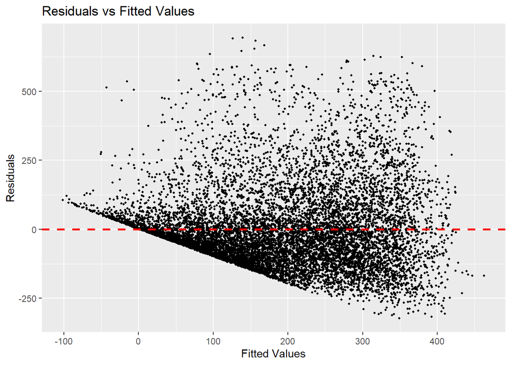

```r
# Plotting the residuals
library(ggplot2)

ggplot(data = train_data, aes(x = fitted(lm_model), y = residuals(lm_model))) +
  geom_point(size=0.7) +
  geom_hline(yintercept = 0, linetype = "dashed", color = "red",size=1) +
  labs(title = "Residuals vs Fitted Values", x = "Fitted Values", y = "Residuals")
```

The model explains a moderate proportion of the variance (Multiple R-squared = 0.338) in the dependent variable, with significant contributions from several predictors. However, the wide range of residuals suggests there may be some outliers or that the model may not capture all the variability in the data.

Let’s then try **Random Forest**.

```r
library(randomForest, quietly = TRUE)
library(lubridate, quietly = TRUE)
library(ggplot2, quietly = TRUE)

# Ensure datetime is in the correct format
train_data$datetime <- ymd_hms(train_data$datetime)

# Extract hour, weekday, and month from datetime
train_data$hour <- hour(train_data$datetime)
train_data$weekday <- wday(train_data$datetime)
train_data$month <- month(train_data$datetime)

# Excluding 'casual' and 'registered' because these are only user information
model_formula <- count ~ season + holiday + workingday + weather + temp +
                 atemp + humidity + windspeed + hour + weekday + month

# Fit the Random Forest model with 500 trees
rf_model <- randomForest(model_formula, data=train_data, ntree=500, importance=TRUE)

print(rf_model)
```

```
##
## Call:
##  randomForest(formula = model_formula, data = train_data, ntree = 500,      importance = TRUE)
##                Type of random forest: regression
##                      Number of trees: 500
## No. of variables tried at each split: 3
##
##           Mean of squared residuals: 5021.145
##                     % Var explained: 84.7
```

Now, let’s try to furthur improve the model by **cross-validation**.

```r
# Load necessary libraries
if (!require(caret)) install.packages("caret", dependencies = TRUE)
library(caret)
library(randomForest)
```

```r
# Ensure datetime is in the correct format
train_data$datetime <- ymd_hms(train_data$datetime)

# Extract hour, weekday, and month from datetime
train_data$hour <- hour(train_data$datetime)
train_data$weekday <- wday(train_data$datetime)
train_data$month <- month(train_data$datetime)

train_data <- na.omit(train_data)

# Define the formula
model_formula <- count ~ season + holiday + workingday + weather + temp + atemp + humidity + windspeed + hour + weekday + month

# Set up cross-validation
train_control <- trainControl(
  method = "cv",
  number = 10,
  verboseIter = TRUE
)

# Fit the Random Forest model using cross-validation
set.seed(123)  # For reproducibility
rf_model_cv <- train(
  model_formula,
  data = train_data,
  method = "rf",
  trControl = train_control,
  ntree = 500
)
# Output the results
print(rf_model_cv)
```

```
## Random Forest
##
## 10431 samples
##    11 predictor
##
## No pre-processing
## Resampling: Cross-Validated (10 fold)
## Summary of sample sizes: 9387, 9388, 9389, 9389, 9387, 9388, ...
## Resampling results across tuning parameters:
##
##   mtry  RMSE      Rsquared   MAE
##    2    86.61873  0.7971430  58.80559
##    6    64.58122  0.8762752  43.21229
##   11    66.38043  0.8679513  44.35605
##
## RMSE was used to select the optimal model using the smallest value.
## The final value used for the model was mtry = 6.
```

```r
summary(rf_model_cv)
```

```
##                 Length Class      Mode
## call                5  -none-     call
## type                1  -none-     character
## predicted       10431  -none-     numeric
## mse               500  -none-     numeric
## rsq               500  -none-     numeric
## oob.times       10431  -none-     numeric
## importance         11  -none-     numeric
## importanceSD        0  -none-     NULL
## localImportance     0  -none-     NULL
## proximity           0  -none-     NULL
## ntree               1  -none-     numeric
## mtry                1  -none-     numeric
## forest             11  -none-     list
## coefs               0  -none-     NULL
## y               10431  -none-     numeric
## test                0  -none-     NULL
## inbag               0  -none-     NULL
## xNames             11  -none-     character
## problemType         1  -none-     character
## tuneValue           1  data.frame list
## obsLevels           1  -none-     logical
## param               1  -none-     list
```